# Site Coordination Group

The Lebanon Site Coordination Group is part of the Shelter & Collective Site Coordination Sector, part of the humanitarian contingency planning and response.

# Introduction

# Site List

The map below shows approximate locations of current IDP sites, pre-identified contingency sites that have followed a site suitability assessment, and UNRWA sites.

[Add a new site](https://ee.kobo.iom.int/x/NT4RDwUK) [Suggest edit/duplicate](https://ee.kobo.iom.int/x/801xyUJM)

[interactive chart not shown]

*Click here to view the map in full-screen.*

The locations shown are approximated to reduce risks. Humanitarian partners can request the full data by reaching out to the Sector directly.

# Partners

# Activities

**Level 1: Key activities under Crisis Preparedness and Planning**

[output not shown]

# Analysis

## Impacts

### Conflict Events

[interactive chart not shown]

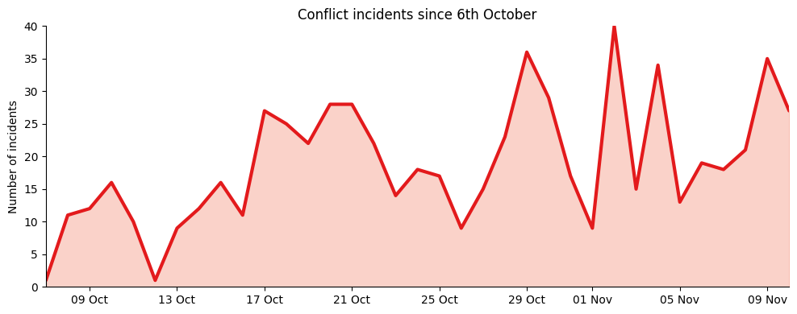

### Impact on systems and services

The following images show night-time light lumincescence on 9th September and 9th November. There are no discernable wide-area changes.

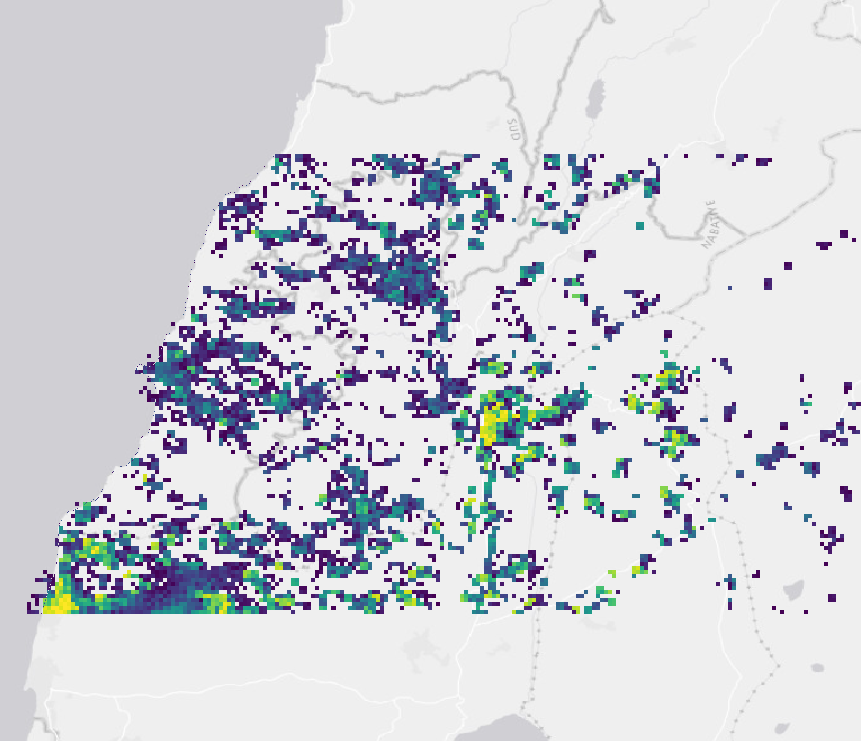

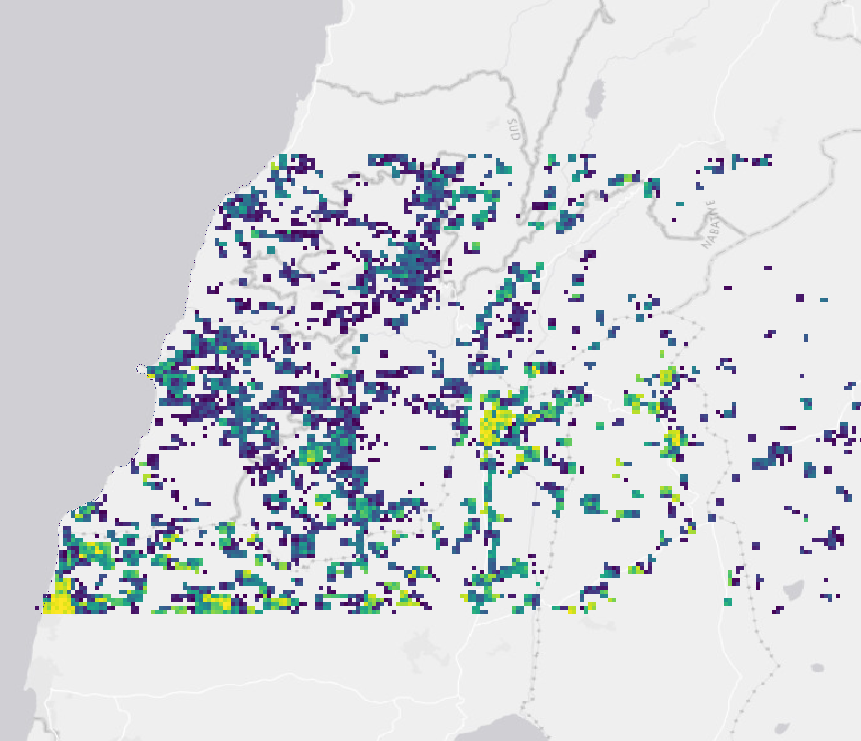

## Governorate-level trends

The following charts show the estimated net change in governorate-level population, for Nabatieh and South Governorates, against a 11th October baseline, based on social media usage.

[figure not shown]

This data is updated daily

[figure not shown]